# Lecture 4 Exercises

# Exercise 1

First, load libraries.

```r
library(ISLR)
library(ggplot2)
library(gridExtra)
library(class)
library(MASS)
```

Get rid of old stuff

```r
rm(list=ls())
par(mfrow=c(1,1))
```

set printing preferences

```r
options(scipen=99)
options(digits=4)
```

Explore “default” dataset

```r
summary(Default)
```

```
 default    student       balance         income
 No :9667   No :7056   Min.   :   0   Min.   :  772
 Yes: 333   Yes:2944   1st Qu.: 482   1st Qu.:21340
                       Median : 824   Median :34553
                       Mean   : 835   Mean   :33517
                       3rd Qu.:1166   3rd Qu.:43808
                       Max.   :2654   Max.   :73554
```

```r
attach(Default)
```

Display the distribution of balance and income

```r
p1 <- ggplot(data = Default, mapping = aes(x = balance, y = income)) + geom_point(mapping = aes(col = default))
p2 <- ggplot(data = Default, mapping = aes(x = default, y = balance, fill = default)) + geom_boxplot()
p3 <- ggplot(data = Default, mapping = aes(x = default, y = income, fill = default)) + geom_boxplot()
grid.arrange(p1, p2, p3, nrow = 1, widths = c(2,2,2))
par(mfrow=c(1,1))
```

[output not shown]

Create training and test data

```r
indices <- sort(sample(1:max(balance), 100)) # select 100 samples
test.data <- Default[indices,]
training.data <- Default[-indices,]
p1 <- ggplot() + geom_point(data = training.data, aes(x=balance, y=default), color='steelblue3') + geom_point(data = test.data,aes(x=balance, y=default), color='darkred', size =4)
p2 <- ggplot() + geom_point(data = training.data, aes(x=balance, y=income), color='steelblue3') + geom_point(data = test.data,aes(x=balance, y=income), color='darkred', size =4)
grid.arrange(p1,p2, nrow=1)
```

[output not shown]

Try to interpret the plots. 1. What patterns can you observe? People who default have a higher balance than those do do not.

2. What characteristics of the data catch your eye? There does not appear to be a correlation between income and balance or between income and default.

# Exercise 2

Applying and Evaluating k-Nearest Neighbors

Convert training and test data to k-NN specific format

```r
training.data.predictors <- cbind(training.data$balance, training.data$income)
test.data.predictors <- cbind(test.data$balance, test.data$income)
training.data.class <- training.data$default
```

Fit the k-NN model with k=1

```r
set.seed (1)
knn.pred <- knn(training.data.predictors, test.data.predictors, training.data.class, k=1)
```

Confusion Matrix

```r
table(knn.pred, test.data$default)
```

```
knn.pred No Yes
     No  94   5
     Yes  1   0
```

Estimate the test error rate

```r
mean(knn.pred != test.data$default)
```

```
[1] 0.06
```

Try with k = 3

```r
set.seed (1)
knn.pred <- knn(training.data.predictors, test.data.predictors, training.data.class, k=3)
table(knn.pred, test.data$default)
```

```
knn.pred No Yes
     No  94   5
     Yes  1   0
```

```r
mean(knn.pred != test.data$default)
```

```
[1] 0.06
```

Try with k = 100

```r
set.seed (1)
knn.pred <- knn(training.data.predictors, test.data.predictors, training.data.class, k=100)
table(knn.pred, test.data$default)
```

```
knn.pred No Yes
     No  95   5
     Yes  0   0
```

```r
mean(knn.pred != test.data$default)
```

```
[1] 0.05
```

# Fitting a Logistic Regression Model

Logistic Regression with 1 Predictor (One Predictor)

Fitting a logistical regression model to the training data

```r
glm.fit <- glm(default~balance, family="binomial", data = training.data)
summary(glm.fit)
```

```
Call:
glm(formula = default ~ balance, family = "binomial", data = training.data)

Deviance Residuals:
   Min      1Q  Median      3Q     Max
-2.263  -0.146  -0.059  -0.022   3.759

Coefficients:
              Estimate Std. Error z value            Pr(>|z|)
(Intercept) -10.647146   0.363385   -29.3 <0.0000000000000002 ***
balance       0.005491   0.000222    24.8 <0.0000000000000002 ***
---
Signif. codes:  0 ‘***’ 0.001 ‘**’ 0.01 ‘*’ 0.05 ‘.’ 0.1 ‘ ’ 1

(Dispersion parameter for binomial family taken to be 1)

    Null deviance: 2880.2  on 9899  degrees of freedom
Residual deviance: 1575.2  on 9898  degrees of freedom
AIC: 1579

Number of Fisher Scoring iterations: 8
```

# Exercise 4 - Making Prediction

Predicting the training data

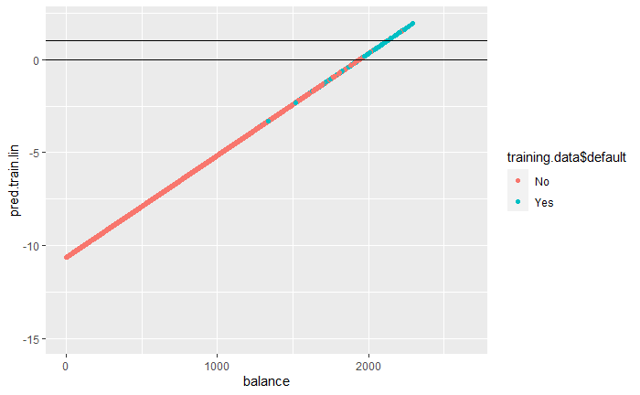

```r
pred.train.lin <- predict(glm.fit) # No data set is supplied to the predict() function: the probabilities are computed for the training data that was used to fit the logistic regression model.
# Notice: Without the type option specified in predict() we get the linear predictor scale (see plot below)
pred.train.lin.df <- data.frame(balance = training.data$balance, pred.train.lin=pred.train.lin) # make it a data frae for plotting
ggplot() +
  geom_point(data = pred.train.lin.df, aes(x = balance, y = pred.train.lin, col = training.data$default)) +
  geom_hline(yintercept = 0) +
  geom_hline(yintercept = 1) +
  ylim(-15,2) # plot
```

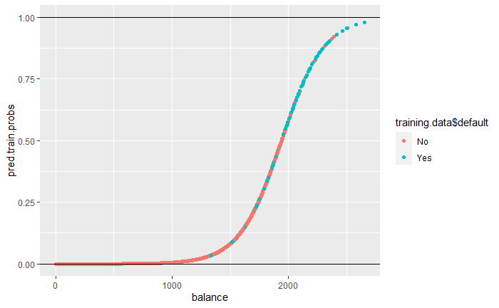

```r
pred.train.probs <- predict(glm.fit, type = "response") # with type = "response", we get the response variable scale, i.e., the probabilities
pred.train.probs.df <- data.frame(balance = training.data$balance, pred.train.probs=pred.train.probs) # make it a data frame for plotting
ggplot() +
  geom_point(data = pred.train.probs.df, aes(x = balance, y = pred.train.probs, col=training.data$default)) +
  geom_hline(yintercept = 0) +
  geom_hline(yintercept = 1) # plot
```

## Predicting the TEST data PROBABILITIES

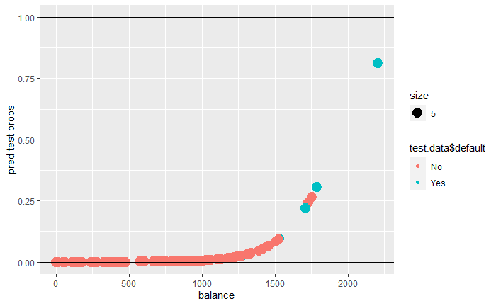

```r
pred.test.probs <- predict(glm.fit, test.data, type = "response")
pred.test.probs.df <- data.frame(balance = test.data$balance, pred.test.probs=pred.test.probs) # make it a data frame for plotting
ggplot() +
  geom_point(data = pred.test.probs.df, aes(x = balance, y = pred.test.probs, col = test.data$default, size = 5)) +
  geom_hline(yintercept = 0) +
  geom_hline(yintercept = 1) +
  geom_hline(yintercept = 0.5, linetype = "dashed") +
  ylim(0,1)
```

Predict the TEST data CLASSES

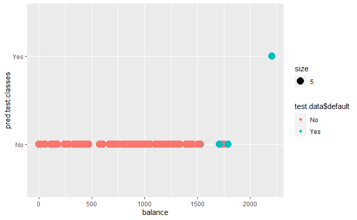

```r
pred.test.classes <- rep("No", nrow(test.data)) # In order to predict the classes, we must convert the predictions into class labels, Yes or No. We start by converting all to No.
pred.test.classes[pred.test.probs > 0.5] <- "Yes" # Set to Yes all with probability greater than 50%
pred.test.classes.df <- data.frame(balance = test.data$balance, pred.test.classes = pred.test.classes) # make it a data frame for plotting
ggplot() +
  geom_point(data = pred.test.classes.df, aes(x = balance, y = pred.test.classes, col = test.data$default, size = 5))
```

Confusion Matrix

```r
table(test.data$default, pred.test.classes)
```

```
     pred.test.classes
      No Yes
  No  95   0
  Yes  4   1
```

Calculating the validation error rate (percentage of incorrectly classified samples) as an estimate of the test error rate

```r
mean(pred.test.classes != test.data$default)
```

```
[1] 0.04
```

Predicting probabilities and classes for a balance of 1000 and 2000 dollars.

```r
new.data <- data.frame(student = c("No", "No"), balance = c(1000, 2000), income = c(1000, 2000)) # student and income and arbitrarily set, since they will not be used to predict
predict(glm.fit, newdata = new.data, type = "response")
```

```
       1        2
0.005729 0.582820
```

# Exercise 5 - Making Predictions with Multiple Predictors

Logistical regression with more than one predictor (including qualitative predictors)

```r
glm.fit <- glm(default~balance + student +income, family = "binomial", data = Default)
summary(glm.fit)
```

```
Call:
glm(formula = default ~ balance + student + income, family = "binomial",
    data = Default)

Deviance Residuals:
   Min      1Q  Median      3Q     Max
-2.469  -0.142  -0.056  -0.020   3.738

Coefficients:
                Estimate   Std. Error z value            Pr(>|z|)
(Intercept) -10.86904520   0.49225552  -22.08 <0.0000000000000002 ***
balance       0.00573651   0.00023189   24.74 <0.0000000000000002 ***
studentYes   -0.64677581   0.23625253   -2.74              0.0062 **
income        0.00000303   0.00000820    0.37              0.7115
---
Signif. codes:  0 ‘***’ 0.001 ‘**’ 0.01 ‘*’ 0.05 ‘.’ 0.1 ‘ ’ 1

(Dispersion parameter for binomial family taken to be 1)

    Null deviance: 2920.6  on 9999  degrees of freedom
Residual deviance: 1571.5  on 9996  degrees of freedom
AIC: 1580

Number of Fisher Scoring iterations: 8
```

Predicting probabilities and classes for a balance of 1000 and 2000 dollars

```r
new.data <- data.frame(student = c("No", "No"), balance = c(1000,2000), income = c(1000,2000)) # student and income arbitrary, since not used to predict
predict(glm.fit, newdata = new.data, type = "response")
```

```
       1        2
0.005885 0.647948
```

# Lecture 5 Start

A continuation of Lecture 4, above

# LDA - Linear Discriminant Analyses

Fitting the model to the training data

```r
(lda.fit <- lda(default~balance, data = training.data))
```

```
Call:
lda(default ~ balance, data = training.data)

Prior probabilities of groups:
     No     Yes
0.96687 0.03313

Group means:
    balance
No    803.9
Yes  1748.5

Coefficients of linear discriminants:
             LD1
balance 0.002207
```

“Group means” … class mean estimates “Coefficients of linear discriminants” … slope k of the discriminant function d(s)=kx+d

histograms of the linear discriminants

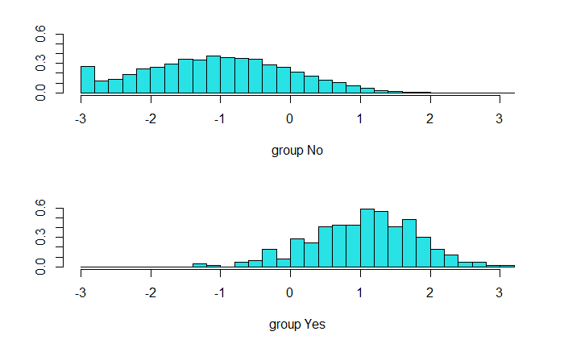

```r
plot(lda.fit)
```

“Discriminant” … k*x Discriminants are used to build the decision rule for classification (because the intercept does not depend on x): kx small -> No kx big -> Yes

1. Try to interpret the group means and the slope of the discriminant function. What does it tell you about our data? People who do not default have on average a lower balance than people who do default. The slope tells us how the probability of default increases with balance.
2. Try to understand the outputs of the plots and interpret them. It shows the number of cases for No and Yes defaults. I assume the x-axis is standard deviations from the mean balance, and the y-axis is the probability of the classification assignment?

## Predicting test data

```r
lda.pred >- predict(lda.fit, test.data)
```

[output not shown]

Interpretation: class … predicted class label (Yes or No)

```r
head(lda.pred$class)
```

```
[1] No No No No No No
Levels: No Yes
```

posterior … posterior probability of belonging to a class

```r
head(lda.pred$posterior)
```

```
        No        Yes
14  0.9984 0.00157200
22  0.9923 0.00773041
63  0.9999 0.00009653
87  0.9902 0.00975053
112 0.9985 0.00150295
148 0.9694 0.03062997
```

x … linear discriminants

```r
head(lda.pred$x)
```

```
        LD1
14  -0.5041
22   0.2629
63  -1.8432
87   0.3752
112 -0.5257
148  0.9344
```

Plotting the predicted classes

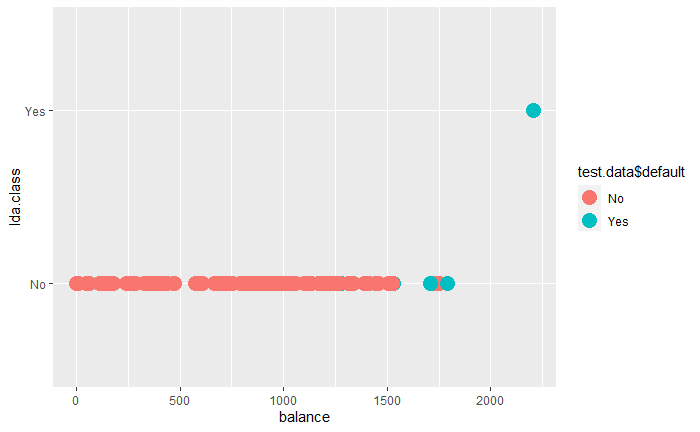

```r
lda.class <- lda.pred$class
lda.class.df <- data.frame(balance=test.data$balance,lda.class=lda.class) # make it a data frame for plotting
(p1 <- ggplot() + geom_point(data = lda.class.df, aes(x=balance, y = lda.class, col=test.data$default), size = 5))
```

Calculating the validation error rate (percentage of incorrectly classified samples) as an estimate of the test error rate

```r
mean(lda.class != test.data$default)
```

```
[1] 0.04
```

Confusion matrix

```r
table(test.data$default,lda.class)
```

```
     lda.class
      No Yes
  No  95   0
  Yes  4   1
```

# Exercise 2 - Varying the Decision Threshold

Recreating the above prediction manually from the probabilities using the same 50% threshold the LDA uses

```r
head(lda.pred$posterior)
```

```
        No        Yes
14  0.9984 0.00157200
22  0.9923 0.00773041
63  0.9999 0.00009653
87  0.9902 0.00975053
112 0.9985 0.00150295
148 0.9694 0.03062997
```

```r
sum(lda.pred$posterior[,2] >=0.5) # how many observations are classified Yes
```

```
[1] 1
```

```r
sum(lda.pred$posterior[,2] < 0.5) # how many observations are classified No
```

```
[1] 99
```

Plotting the predicted classes and probabilities once more

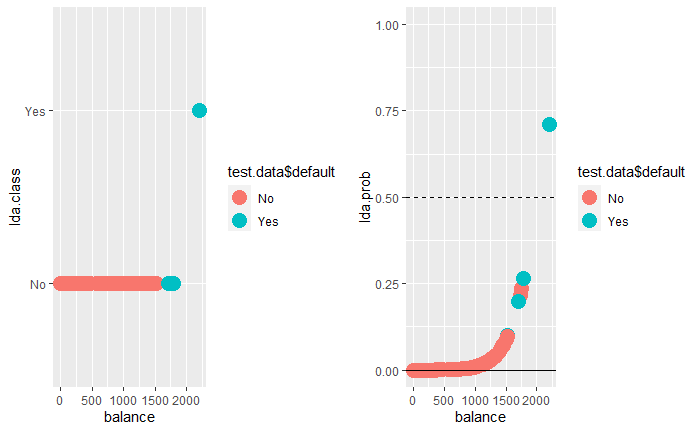

```r
lda.prob.df <- data.frame(balance=test.data$balance, lda.prob=lda.pred$posterior[,2]) # make it a data frame for plotting
p2 <- ggplot() +geom_point(data = lda.prob.df, aes(x = balance, y = lda.prob, col = test.data$default), size = 5) + geom_hline(yintercept = 0) + geom_hline(yintercept = 0.5, linetype = "dashed") + ylim(0,1)
grid.arrange(p1,p2,nrow=1)
par(mfrow=c(1,1))
```

p1 shows the classification, p2 shows the probability of the classification

## Change threshold

Now we change the threshold from 50% to 20% manually 1. Find all observations with posterior probability of >0 0.2 and see how many we have. 2. Manually reclassify them. Create a new fariable lda.reclassified, that we use instead of lda.pred$class. (lda.pred$class is where the predict function had stored the class predictions in exercise 1) 3. Set it to “No” for all observations except the ones with posterior >= 0.2 4. Do the same plots as before, but with the manually reclassified

Imposing a lower threshold for Yes

```r
sum(lda.pred$posterior[,2] >= 0.2) # how many observations will be classified Yes with a 20% threshold
```

```
[1] 4
```

Reclassify

```r
lda.reclassified <- rep("No", length(lda.class))
lda.reclassified[lda.pred$posterior[,2] >= 0.2] <- "Yes"
```

Plotting the new classification

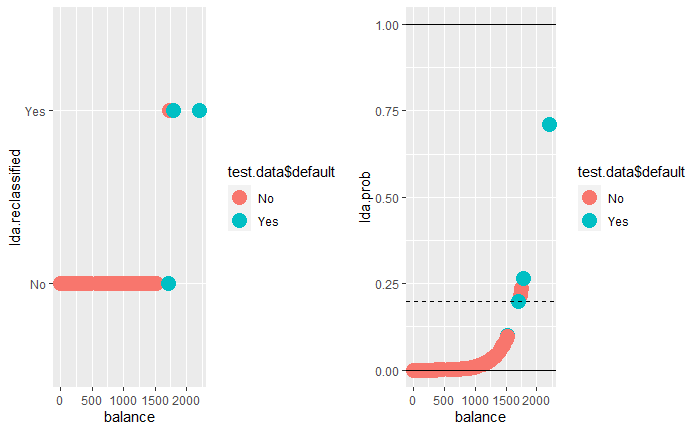

```r
        lda.reclassified.df <- data.frame(balance=test.data$balance,lda.reclassified=lda.reclassified) # make a data frame for plotting
        p3 <- ggplot() + geom_point(data = lda.reclassified.df, aes(x=balance, y=lda.reclassified, col=test.data$default), size=5)
        lda.prob.df <- data.frame(balance=test.data$balance,lda.prob=lda.pred$posterior[,2]) # make a data frame for plotting
        p4 <- ggplot() + geom_point(data = lda.prob.df, aes(x=balance, y=lda.prob, col=test.data$default), size=5) +
          geom_hline(yintercept = 0) + geom_hline(yintercept = 1) + geom_hline(yintercept = 0.2, linetype="dashed") + ylim(0,1)
        grid.arrange(p3, p4, nrow = 1)
        par(mfrow=c(1,1))
```

It reclassifies some of the Nos into Yeses because of the adjusted cutoff.